# Index:

# 0. Introduction

This Python notebook demonstrates a step-by-step process for detecting spam SMS messages by building and comparing various machine learning classification models. Our goal is to explore the performance of different algorithms and identify the best model for accurately classifying SMS as spam or not.

The classification models we evaluate include:

- **Logistic Regression (LR)**
- **Decision Tree Classifier (DT)**
- **Random Forest Classifier (RF)**
- **Support Vector Classifier (SVC)**
- **K-Nearest Neighbors Classifier (K-NN)**
- **Multinomial Naive Bayes**
- **AdaBoost Classifier**
- **Bagging Classifier (Bgc)**
- **Gradient Boosting Decision Trees (GBDT)**
- **XGBoost Classifier**
- **Extra Trees Classifier (ETC)**

By comparing these models, we aim to determine which algorithm offers the best performance for detecting spam in SMS messages, ensuring both accuracy and efficiency.

# 1. Libraries Imports

```python
# Essential Libraries
import pandas as pd
import matplotlib.pyplot as plt
import seaborn as sns

# Natural Language Processing (NLP) with NLTK
import nltk
from nltk.corpus import stopwords            # Stopword removal
from nltk.tokenize import word_tokenize      # Tokenization
from nltk.stem.porter import PorterStemmer   # Stemming
import string                                # Handling special characters

# Download NLTK resources
nltk.download('stopwords')                   # Stopwords list
nltk.download('punkt')                       # Tokenization rules

# Visualization Tools
from wordcloud import WordCloud              # Word Cloud Visualization
from collections import Counter              # Word frequency counter

# Feature Extraction and Text Transformation
from sklearn.feature_extraction.text import CountVectorizer, TfidfTransformer
from sklearn.model_selection import train_test_split

# Evaluation Metrics
from sklearn.metrics import accuracy_score, precision_score, classification_report, confusion_matrix

# Machine Learning Classifiers
from sklearn.linear_model import LogisticRegression
from sklearn.svm import SVC
from sklearn.naive_bayes import MultinomialNB
from sklearn.tree import DecisionTreeClassifier
from sklearn.neighbors import KNeighborsClassifier
from sklearn.ensemble import (
    RandomForestClassifier, AdaBoostClassifier, BaggingClassifier,
    ExtraTreesClassifier, GradientBoostingClassifier
)
from xgboost import XGBClassifier            # XGBoost Classifier
```

# 2. Initial Data Inspection

```python
df = pd.read_csv('./spam.csv', encoding='latin-1')
df.head()
```

|  | v1 | v2 | Unnamed: 2 | Unnamed: 3 | Unnamed: 4 |
| --- | --- | --- | --- | --- | --- |
| 0 | ham | Go until jurong point, crazy.. Available only ... | NaN | NaN | NaN |
| 1 | ham | Ok lar... Joking wif u oni... | NaN | NaN | NaN |
| 2 | spam | Free entry in 2 a wkly comp to win FA Cup fina... | NaN | NaN | NaN |
| 3 | ham | U dun say so early hor... U c already then say... | NaN | NaN | NaN |
| 4 | ham | Nah I don't think he goes to usf, he lives aro... | NaN | NaN | NaN |

```python
df.info()
```

```
<class 'pandas.core.frame.DataFrame'>
RangeIndex: 5572 entries, 0 to 5571
Data columns (total 5 columns):
 #   Column      Non-Null Count  Dtype
---  ------      --------------  -----
 0   v1          5572 non-null   object
 1   v2          5572 non-null   object
 2   Unnamed: 2  50 non-null     object
 3   Unnamed: 3  12 non-null     object
 4   Unnamed: 4  6 non-null      object
dtypes: object(5)
memory usage: 217.8+ KB
```

```python
df.describe()
```

|  | v1 | v2 | Unnamed: 2 | Unnamed: 3 | Unnamed: 4 |
| --- | --- | --- | --- | --- | --- |
| count | 5572 | 5572 | 50 | 12 | 6 |
| unique | 2 | 5169 | 43 | 10 | 5 |
| top | ham | Sorry, I'll call later | bt not his girlfrnd... G o o d n i g h t . . .@" | MK17 92H. 450Ppw 16" | GNT:-)" |
| freq | 4825 | 30 | 3 | 2 | 2 |

# 3. Data Cleaning

```python
df = df[['v1', 'v2']]
df.rename(columns = {'v1': 'label', 'v2': 'message'}, inplace = True)
df['label'] = df['label'].map({'ham': 0, 'spam': 1})
df.head()
```

|  | label | message |
| --- | --- | --- |
| 0 | 0 | Go until jurong point, crazy.. Available only ... |
| 1 | 0 | Ok lar... Joking wif u oni... |
| 2 | 1 | Free entry in 2 a wkly comp to win FA Cup fina... |
| 3 | 0 | U dun say so early hor... U c already then say... |
| 4 | 0 | Nah I don't think he goes to usf, he lives aro... |

```python
df.isnull().sum()
```

```
label      0
message    0
dtype: int64
```

```python
df.duplicated().sum()
```

```
403
```

```python
df = df.drop_duplicates(keep = 'first')
df.shape
```

```
(5169, 2)
```

# 4. Exploratory Data Analysis (EDA)

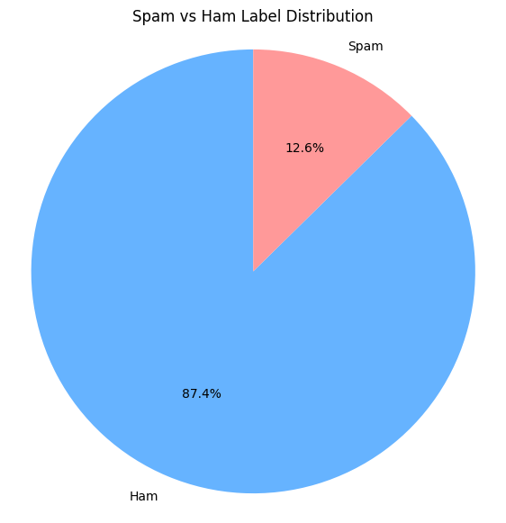

```python
# Calculate the count of each label (spam vs ham)
label_counts = df['label'].value_counts()

# Define labels and sizes
labels = ['Ham', 'Spam']
sizes = [label_counts[0], label_counts[1]]

# Define colors for each section of the pie
colors = ['#66b3ff', '#ff9999']

# Plot the pie chart
plt.figure(figsize=(7,7))
plt.pie(sizes, labels=labels, colors=colors, autopct='%1.1f%%', startangle=90)
plt.title('Spam vs Ham Label Distribution')
plt.axis('equal')  # Equal aspect ratio ensures that pie is drawn as a circle.
plt.show()
```

```
count    5169.000000
mean       78.977945
std        58.236293
min         2.000000
25%        36.000000
50%        60.000000
75%       117.000000
max       910.000000
Name: text_length, dtype: float64
```

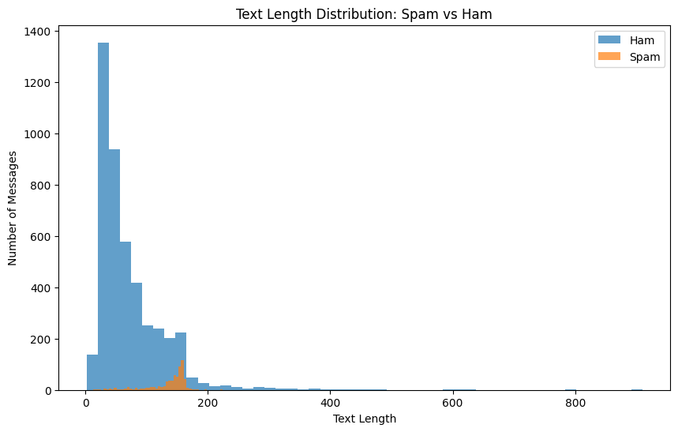

```python
# Calculate message length
df['text_length'] = df['message'].apply(len)

# Descriptive statistics of message lengths
print(df['text_length'].describe())

# Visualize text length distribution for spam and ham
plt.figure(figsize=(10,6))
df[df['label'] == 0]['text_length'].plot(kind='hist', bins=50, alpha=0.7, label='Ham')
df[df['label'] == 1]['text_length'].plot(kind='hist', bins=50, alpha=0.7, label='Spam')
plt.legend()
plt.title('Text Length Distribution: Spam vs Ham')
plt.xlabel('Text Length')
plt.ylabel('Number of Messages')
plt.show()
```

# 5. Data Preprocessing

```python
stop_words = set(stopwords.words('english'))

# Creating an instance of the Porter Stemmer
stemmer = PorterStemmer()

def preprocess_text(text):
    # Lower case
    text = text.lower()

    # Tokenize the text
    tokens = word_tokenize(text)

    # Remove special characters, stopwords and punctuation
    tokens = [word for word in tokens if word.isalnum() and word not in stop_words and word not in string.punctuation]

    # Perform stemming
    tokens = [stemmer.stem(word) for word in tokens]

    # Join tokens back into a string
    text = ' '.join(tokens)

    return text

df['transformed_message'] = df['message'].apply(preprocess_text)
df.head()
```

|  | label | message | text_length | transformed_message |
| --- | --- | --- | --- | --- |
| 0 | 0 | Go until jurong point, crazy.. Available only ... | 111 | go jurong point crazi avail bugi n great world... |
| 1 | 0 | Ok lar... Joking wif u oni... | 29 | ok lar joke wif u oni |
| 2 | 1 | Free entry in 2 a wkly comp to win FA Cup fina... | 155 | free entri 2 wkli comp win fa cup final tkt 21... |
| 3 | 0 | U dun say so early hor... U c already then say... | 49 | u dun say earli hor u c alreadi say |
| 4 | 0 | Nah I don't think he goes to usf, he lives aro... | 61 | nah think goe usf live around though |

# 6. Advance EDA

```python
# Function to plot bar charts for word frequency
def plot_word_frequency(df, title):
    plt.figure(figsize=(10, 6))
    sns.barplot(data = df, x = df[0], y = df[1], palette = 'bright')
    plt.title(title)
    plt.xlabel('Words')
    plt.ylabel('Frequency')
    plt.xticks(rotation=45)
    plt.tight_layout()
    plt.show()
```

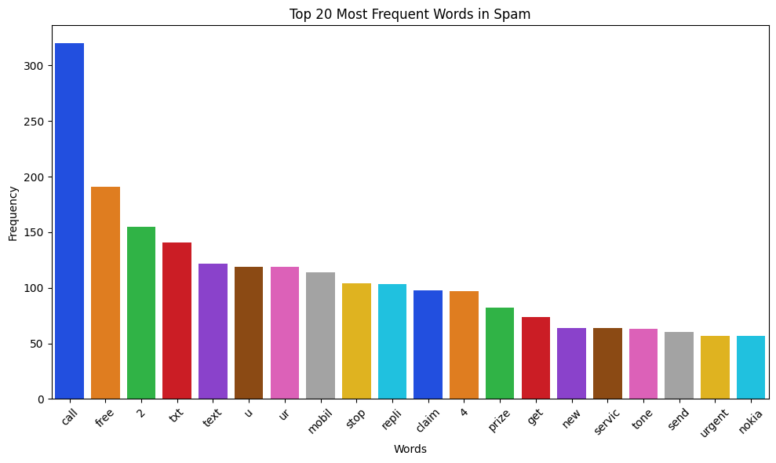

```python
# Plot the word frequency for spam messages
spam_words = []
for message in df[df['label'] == 1]['transformed_message'].tolist():
    for word in message.split():
        spam_words.append(word)

filter_df_spam = pd.DataFrame(Counter(spam_words).most_common(20))

plot_word_frequency(filter_df_spam, 'Top 20 Most Frequent Words in Spam')
```

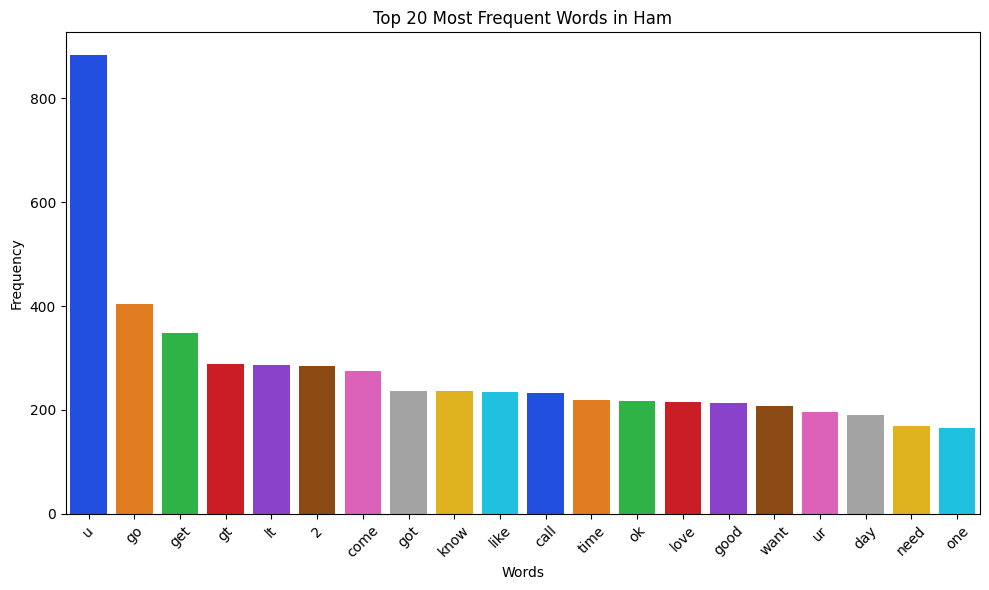

```python
# Plot the word frequency for ham messages
ham_words = []
for message in df[df['label'] == 0]['transformed_message'].tolist():
    for word in message.split():
        ham_words.append(word)

filter_df_ham = pd.DataFrame(Counter(ham_words).most_common(20))

filter_df_spam.head()

plot_word_frequency(filter_df_ham, 'Top 20 Most Frequent Words in Ham')
```

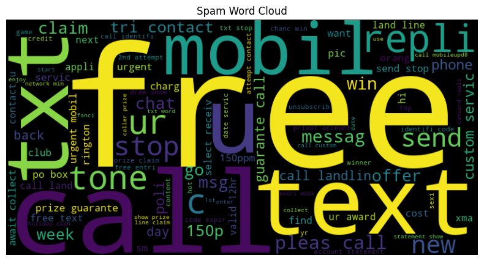

```python
# Generate word cloud for spam messages
spam_wordcloud = WordCloud(width=800, height=400, max_words=100).generate(' '.join(spam_words))
plt.figure(figsize=(10,5))
plt.imshow(spam_wordcloud, interpolation='bilinear')
plt.axis('off')
plt.title('Spam Word Cloud')
plt.show()
```

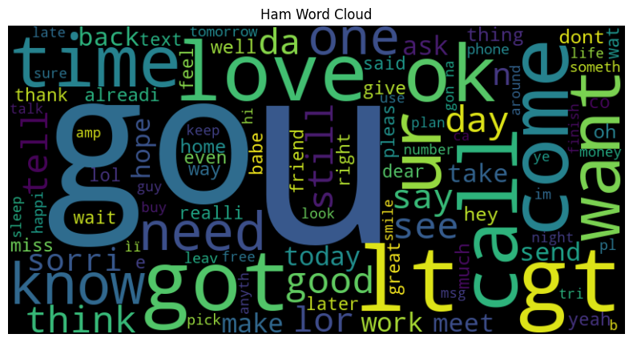

```python
# Generate word cloud for ham messages
ham_wordcloud = WordCloud(width=800, height=400, max_words=100).generate(' '.join(ham_words))
plt.figure(figsize=(10,5))
plt.imshow(ham_wordcloud, interpolation='bilinear')
plt.axis('off')
plt.title('Ham Word Cloud')
plt.show()
```

# 7. Model Training, Prediction and Evaluation

```python
# Transform into a sparse matrix of word counts
vectorizer = CountVectorizer()
X = vectorizer.fit_transform(df['message'])

# Fit the transformer to the word count matrix and transform it into a TF-IDF matrix
tfidf_transformer = TfidfTransformer()
X_tfidf = tfidf_transformer.fit_transform(X)

y = df['label']
```

```python
# Initiate models
svc = SVC(kernel= "sigmoid", gamma  = 1.0)
knc = KNeighborsClassifier()
mnb = MultinomialNB()
dtc = DecisionTreeClassifier(max_depth = 5)
lrc = LogisticRegression(solver = 'liblinear', penalty = 'l1')
rfc = RandomForestClassifier(n_estimators = 50, random_state = 2 )
abc = AdaBoostClassifier(n_estimators = 50, random_state = 2)
bc = BaggingClassifier(n_estimators = 50, random_state = 2)
etc = ExtraTreesClassifier(n_estimators = 50, random_state = 2)
gbdt = GradientBoostingClassifier(n_estimators = 50, random_state = 2)
xgb  = XGBClassifier(n_estimators = 50, random_state = 2)

clfs = {
    'Support Vector Classifier': svc,
    'K-Nearest Neighbors Classifier': knc,
    'Multinomial Naive Bayes': mnb,
    'Decision Tree Classifier': dtc,
    'Logistic Regression': lrc,
    'Random Forest Classifier': rfc,
    'AdaBoost Classifier': abc,
    'Bagging Classifier': bc,
    'Extra Trees Classifier': etc,
    'Gradient Boosting Decision Trees': gbdt,
    'XGBoost Classifier': xgb

}
```

```python
# Train the models, make predictions, and return evaluation metrics
X_train, X_test, y_train, y_test = train_test_split(X_tfidf, y, test_size=0.2, random_state=42)
def train_models(clfs, X_train, y_train, X_test, y_test):
    clfs.fit(X_train,y_train)
    y_pred = clfs.predict(X_test)
    accuracy = accuracy_score(y_test, y_pred)
    precision = precision_score(y_test, y_pred)
    report = classification_report(y_test, y_pred)
    confus_matrix = confusion_matrix(y_test, y_pred)

    return accuracy , precision, report, confus_matrix
```

```python
# Print the performance of each model
for name , clfs in clfs.items():
    accuracy, precision, report, confus_matrix = train_models(clfs, X_train, y_train, X_test, y_test)
    print()
    print("Model: ", name)
    print("Accuracy: ", accuracy)
    print("Precision: ", precision)
    print("Classfication Report: \n", report)
    print("confusion_matrix: \n", confus_matrix)
```

```
Model:  Support Vector Classifier
Accuracy:  0.9835589941972921
Precision:  0.9776119402985075
Classfication Report:
               precision    recall  f1-score   support

           0       0.98      1.00      0.99       889
           1       0.98      0.90      0.94       145

    accuracy                           0.98      1034
   macro avg       0.98      0.95      0.96      1034
weighted avg       0.98      0.98      0.98      1034

confusion_matrix:
 [[886   3]
 [ 14 131]]

Model:  K-Nearest Neighbors Classifier
Accuracy:  0.8994197292069632
Precision:  1.0
Classfication Report:
               precision    recall  f1-score   support

           0       0.90      1.00      0.94       889
           1       1.00      0.28      0.44       145

    accuracy                           0.90      1034
   macro avg       0.95      0.64      0.69      1034
weighted avg       0.91      0.90      0.87      1034

confusion_matrix:
 [[889   0]
 [104  41]]

Model:  Multinomial Naive Bayes
Accuracy:  0.9555125725338491
Precision:  1.0
Classfication Report:
               precision    recall  f1-score   support

```

[output cut: 46 more lines]

```
Accuracy:  0.97678916827853
Precision:  0.991869918699187
Classfication Report:
               precision    recall  f1-score   support

           0       0.97      1.00      0.99       889
           1       0.99      0.84      0.91       145

    accuracy                           0.98      1034
   macro avg       0.98      0.92      0.95      1034
weighted avg       0.98      0.98      0.98      1034

confusion_matrix:
 [[888   1]
 [ 23 122]]
```

```
Model:  AdaBoost Classifier
Accuracy:  0.9816247582205029
Precision:  0.9632352941176471
Classfication Report:
               precision    recall  f1-score   support

           0       0.98      0.99      0.99       889
           1       0.96      0.90      0.93       145

    accuracy                           0.98      1034
   macro avg       0.97      0.95      0.96      1034
weighted avg       0.98      0.98      0.98      1034

confusion_matrix:
 [[884   5]
 [ 14 131]]

Model:  Bagging Classifier
Accuracy:  0.9777562862669246
Precision:  0.9621212121212122
Classfication Report:
               precision    recall  f1-score   support

           0       0.98      0.99      0.99       889
           1       0.96      0.88      0.92       145

    accuracy                           0.98      1034
   macro avg       0.97      0.94      0.95      1034
weighted avg       0.98      0.98      0.98      1034

confusion_matrix:
 [[884   5]
 [ 18 127]]

Model:  Extra Trees Classifier
Accuracy:  0.9806576402321083
Precision:  1.0
Classfication Report:
               precision    recall  f1-score   support

```

[output cut: 29 more lines]

```
Accuracy:  0.9777562862669246
Precision:  0.9621212121212122
Classfication Report:
               precision    recall  f1-score   support

           0       0.98      0.99      0.99       889
           1       0.96      0.88      0.92       145

    accuracy                           0.98      1034
   macro avg       0.97      0.94      0.95      1034
weighted avg       0.98      0.98      0.98      1034

confusion_matrix:
 [[884   5]
 [ 18 127]]
```

### Comments on the model performances:

1. **Support Vector Classifier (SVC)**:
   - **Accuracy**: 98.36%, **Precision**: 97.76%
   - **Comment**: The SVC performs exceptionally well with both high accuracy and precision. The confusion matrix shows only a few false negatives (14), indicating that most spam messages are detected accurately, though some spam messages are still missed.
   - **Strength**: Excellent overall performance with good balance across precision, recall, and f1-score.
2. **K-Nearest Neighbors (K-NN)**:
   - **Accuracy**: 89.94%, **Precision**: 100%
   - **Comment**: While the precision is perfect, the recall for spam messages (class 1) is poor at 28%, meaning many spam messages are not being detected. The confusion matrix shows that 104 spam messages were incorrectly classified as non-spam.
   - **Weakness**: Very low recall for spam detection, indicating this model is overly conservative in labeling spam.
3. **Multinomial Naive Bayes**:
   - **Accuracy**: 95.55%, **Precision**: 100%
   - **Comment**: This model achieves perfect precision but struggles with recall for spam (68%). While it detects non-spam perfectly, it misses some spam messages. This may be typical for Naive Bayes with imbalanced classes.
   - **Strength**: High precision, meaning it rarely misclassifies non-spam as spam.
4. **Decision Tree Classifier**:
   - **Accuracy**: 95.55%, **Precision**: 95.41%
   - **Comment**: The Decision Tree shows strong performance, but recall for spam is only 72%. It's still missing quite a few spam messages (41), though its accuracy and overall performance are solid.
   - **Strength**: Balanced performance but could improve on recall for spam.
5. **Logistic Regression**:
   - **Accuracy**: 95.74%, **Precision**: 92.44%
   - **Comment**: Logistic Regression offers a good balance, though recall for spam is 76%, missing some spam messages. The model achieves strong overall accuracy and reasonable f1-scores.
   - **Strength**: Solid all-around performance but slightly lower precision and recall compared to other models.
6. **Random Forest Classifier**:
   - **Accuracy**: 97.68%, **Precision**: 99.19%
   - **Comment**: Random Forest performs exceptionally well with very high accuracy and precision. It has strong recall (84%) for spam but still misclassifies 23 spam messages as non-spam.
   - **Strength**: Excellent overall accuracy and performance across all metrics.
7. **AdaBoost Classifier**:
   - **Accuracy**: 98.16%, **Precision**: 96.32%
   - **Comment**: AdaBoost delivers strong results with good precision and recall for spam (90%). It misses only 14 spam messages, making it a reliable option.
   - **Strength**: Very balanced with high precision and recall, making it a strong performer.
8. **Bagging Classifier**:
   - **Accuracy**: 97.78%, **Precision**: 96.21%
   - **Comment**: The Bagging Classifier performs similarly to AdaBoost with high precision and recall. It misses 18 spam messages, but overall the model is highly reliable.
   - **Strength**: Consistent and reliable performance, making it a good choice.
9. **Extra Trees Classifier**:
   - **Accuracy**: 98.07%, **Precision**: 100%
   - **Comment**: Extra Trees shows perfect precision and a strong recall (86%) for spam. It performs very well across the board, with only 20 spam messages misclassified.
   - **Strength**: High precision with a good balance of recall and accuracy.
10. **Gradient Boosting Decision Trees (GBDT)**:
    - **Accuracy**: 96.52%, **Precision**: 98.23%
    - **Comment**: GBDT shows strong performance with high precision and overall accuracy. The recall for spam (77%) is slightly lower, indicating it misses some spam messages (34).
    - **Strength**: Reliable and consistent performance, though it could improve spam recall.
11. **XGBoost Classifier**:
    - **Accuracy**: 97.78%, **Precision**: 96.21%
    - **Comment**: XGBoost delivers strong results with high accuracy, precision, and recall for spam (88%). Only 18 spam messages are missed, making it one of the top performers.
    - **Strength**: Excellent balance of precision, recall, and accuracy.

### General Observations:

In conclusion, we think **Support Vector Classifier** and **AdaBoost** stand out as the most balanced models for this spam detection task, combining high accuracy, precision, and recall.